# Centro de Investigación en Economía y Finanzas - CIENFI

Workshop 02: Introducción a Datos Raster en R

Eduard Fernando Martínez González

eduard-martinez.github.io

[@emartigo](https://twitter.com/emartigo)

eduard-martinez

efmartinez@icesi.edu.co

## **[1.]** Motivación

### **1.1.** Night lights and Covid-19

El análisis de imágenes de luminosidad nocturna se ha consolidado como una herramienta valiosa para aproximar la actividad económica, especialmente durante la pandemia de COVID-19. Diversos estudios han empleado esta fuente de datos para evaluar los efectos económicos de las medidas de confinamiento, así como los patrones de recuperación en diferentes contextos geográficos.

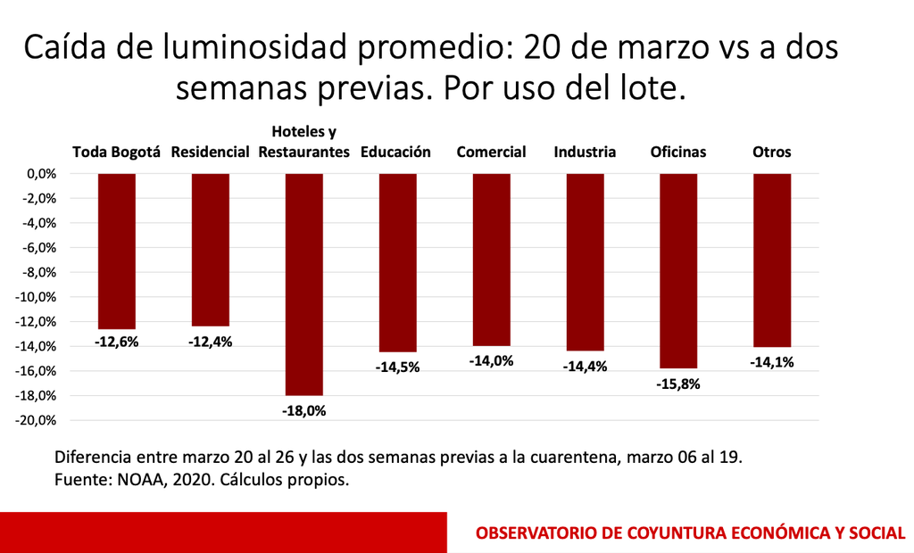

👉 Puede acceder al documento aquí: [COVID19 y actividad económica: demanda de energía y luminosidad ante la emergencia](https://economia.uniandes.edu.co/sites/default/files/observatorio/Resultados-luminosidad.pdf)

Adicionalmente, se ha documentado el uso combinado de datos satelitales de luminosidad con variables de consumo energético para estimar el impacto económico de la pandemia. Un caso representativo es el estudio aplicado a India, que integra ambos indicadores para observar dinámicas económicas diarias durante el confinamiento:

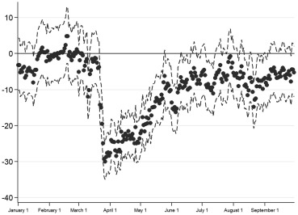

👉 Puede acceder al documento aquí: [Examining the economic impact of COVID-19 in India through daily electricity consumption and nighttime light intensity](https://www.sciencedirect.com/science/article/pii/S0305750X20304149?casa_token=VjcoqRnPQo8AAAAA:DXanp0b9C9w6BvR9C3NF0WfEvWO7uB_DvGBBxC8b8d59l2QVcAdRLGKLf4e-UhGr6HRECXNvxw)

### **1.2.** Measuring the size and growth of cities using nighttime light

La intensidad lumínica registrada por sensores satelitales también ha sido utilizada como proxy para estimar el tamaño y la expansión de las áreas urbanas. Esta metodología ha permitido identificar patrones de crecimiento urbano en ausencia de datos administrativos consistentes.

👉 El estudio puede consultarse en el siguiente enlace: [Measuring the size and growth of cities using nighttime light](https://www.sciencedirect.com/science/article/pii/S0094119020300255?casa_token=cMiibzNrYTEAAAAA:YqwYomGC9QgC81nDaYQmQ_z6Fak1WQgtW6JwobSzTOQCfVsqCzprUGK77XEphlO60A0-eWpPCg)

### **1.3.** Housing Vacancy Rate (VHR) y Luces Nocturnas

La información de luminosidad nocturna también ha sido empleada para estimar la tasa de vacancia habitacional (VHR), integrando imágenes satelitales con datos geoespaciales abiertos como OpenStreetMap. Esta aproximación permite inferir dinámicas del mercado inmobiliario y ocupación urbana con mayor granularidad espacial.

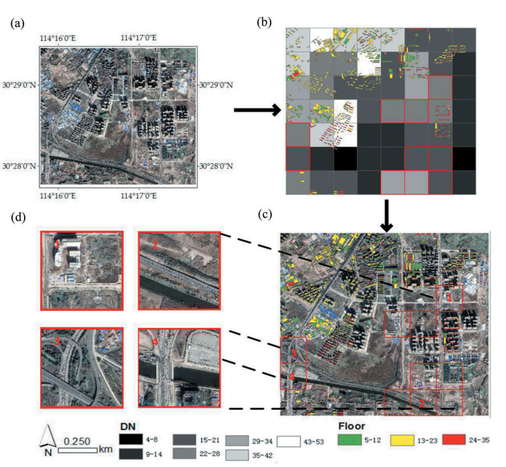

👉 El artículo completo está disponible en: [An estimation of housing vacancy rate using NPP-VIIRS night-time light data and OpenStreetMap data](https://www.tandfonline.com/doi/abs/10.1080/01431161.2019.1615655)

### **1.4.** Causes Of Sprawl: A Portrait From Space

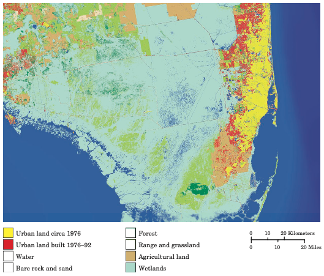

Tomado de: Causes Of Sprawl: A Portrait From Space

👉 Puede acceder al documento aquí: [Causes Of Sprawl: A Portrait From Space](https://diegopuga.org/papers/Burchfield_Overman_Puga_Turner_QJE_2006.pdf)

### **1.5.** Aplicaciones en el sector agrícola e industrial

La integración de imágenes satelitales con algoritmos de inteligencia artificial ha abierto nuevas posibilidades para el monitoreo agrícola y la gestión de riesgos financieros. Bancos y aseguradoras utilizan estas herramientas para evaluar la salud de los cultivos, anticipar pérdidas y definir condiciones crediticias más precisas.

👉 Más información: [EOS Crop Monitoring](https://eos.com/products/crop-monitoring/banks/) - [El País – Revolución tecnológica del campo](https://elpais.com/proyecto-tendencias/2025-02-26/inteligencia-artificial-imagenes-satelitales-y-datos-la-revolucion-tecnologica-del-campo.html)

## **[2.]** Introducción a Datos Raster

### **2.1.** ¿Qué es un raster?

Un raster es una estructura de datos espaciales que representa el territorio como una matriz regular de celdas (píxeles), cada una asociada a un valor numérico. Este valor puede corresponder a una variable continua (como temperatura, altitud o intensidad lumínica) o categórica (como tipo de uso del suelo). Los datos raster son particularmente útiles para representar fenómenos que varían de manera continua en el espacio.

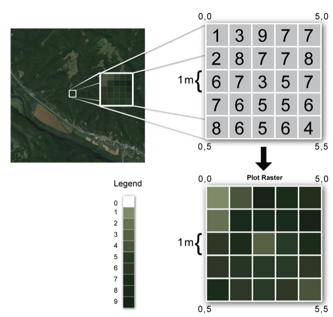

Tomado de: https://www.neonscience.org

### **2.2.** Resolución

La resolución espacial de un raster se refiere al tamaño del área terrestre que representa cada píxel. A mayor resolución (es decir, menor tamaño del píxel), mayor detalle espacial contiene la imagen. Este concepto es clave para interpretar adecuadamente los análisis, ya que la escala de los fenómenos observados debe estar alineada con la resolución del dato satelital utilizado.

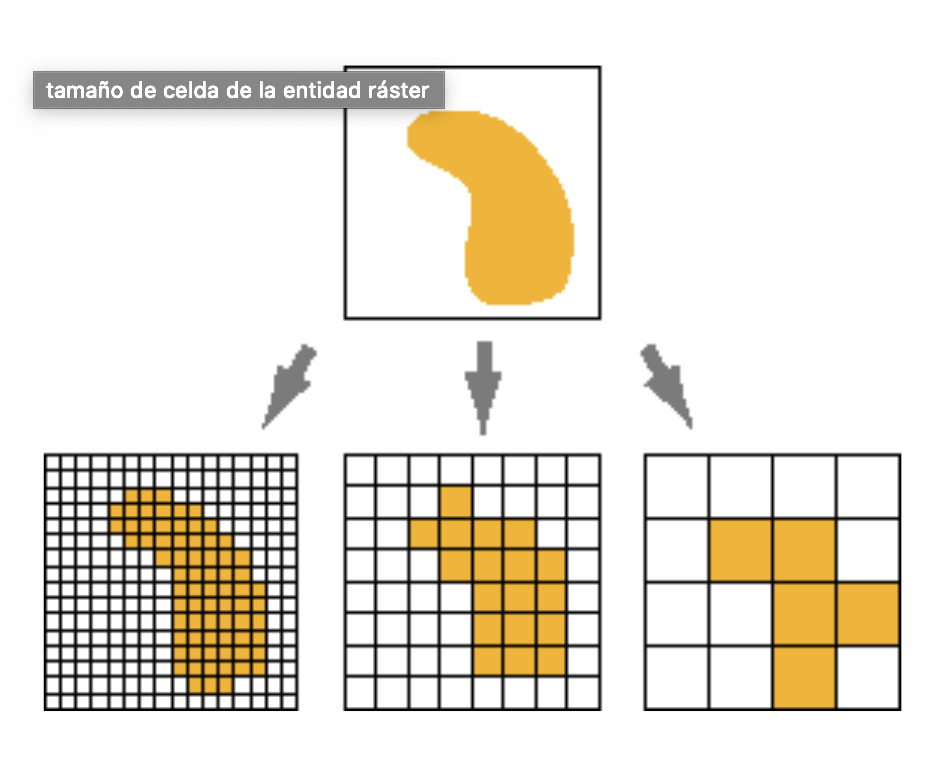

Tomado de: https://www.neonscience.org

### **2.3.** Bandas de un raster

Muchos productos raster, como las imágenes satelitales, están compuestos por múltiples bandas espectrales, que capturan información en distintas longitudes de onda (por ejemplo, rojo, verde, azul o infrarrojo cercano). Estas bandas pueden combinarse para generar visualizaciones (como imágenes RGB) o para calcular índices espectrales, como el NDVI en agricultura.

[figure not shown]

Tomado de: https://www.neonscience.org

### **2.4.** Formatos comunes de datos raster

Los datos raster pueden almacenarse en distintos formatos, dependiendo de su origen, nivel de compresión, metadatos asociados y compatibilidad con software geoespacial. Algunos de los formatos más utilizados en aplicaciones con R y SIG (Sistemas de Información Geográfica) son:

- **GeoTIFF (.tif / .tiff):** Es el formato más común y ampliamente soportado. Permite almacenar información georreferenciada junto con múltiples bandas y metadatos espaciales. Es ideal para análisis con terra en R.
- **NetCDF (.nc):** Utilizado frecuentemente para datos climáticos o multitemporales. Permite almacenar series de tiempo, variables múltiples y dimensiones espaciales complejas.
- **IMG (.img):** Formato utilizado por el software ERDAS Imagine, común en sensores remotos. Puede contener múltiples bandas y datos categóricos o continuos.
- **HDF (.hdf / .h5):** Formato jerárquico utilizado por agencias como la NASA para distribuir productos satelitales complejos (e.g., MODIS). Requiere herramientas específicas para su apertura y conversión.
- **ASCII Raster (.asc):** Representa los valores de las celdas como texto plano, acompañado de una cabecera con metadatos espaciales. Útil para interoperabilidad y edición manual, aunque menos eficiente en términos de almacenamiento.

La elección del formato depende del tipo de análisis, el volumen de datos y el software utilizado. En general, GeoTIFF es el formato recomendado para la mayoría de tareas de análisis raster en R.

### **2.5.** Fuentes:

#### **2.5.1.** Night lights

Una de las fuentes más utilizadas para el análisis de actividad económica y urbana es el producto satelital VIIRS (Visible Infrared Imaging Radiometer Suite), disponible desde el año 2012. Este sensor captura la intensidad de la luz visible durante la noche, lo que permite generar indicadores geoespaciales de actividad humana con alta resolución temporal y espacial.

Los datos de VIIRS están disponibles en diferentes frecuencias de agregación:

👉 Sitio principal del proyecto VIIRS Nighttime Lights: https://eogdata.mines.edu/products/vnl/

👉 Datos mensuales (VNL V.1): https://eogdata.mines.edu/nighttime_light/monthly/v10/

👉 Datos diarios (NOAA - sueltos por mosaico): https://ngdc.noaa.gov/eog/viirs/download_ut_mos.html

Estos archivos suelen estar en formato raster (GeoTIFF) y permiten realizar análisis comparativos en el tiempo, como la detección de apagones, patrones de expansión urbana o impactos económicos de eventos disruptivos.

También se encuentran disponibles productos históricos de luminosidad nocturna provenientes del sensor DMSP-OLS, que cubren el periodo 1992–2013, útiles para análisis de largo plazo: [Datos anuales (DMSP-OLS, 1992–2013)](https://www.ngdc.noaa.gov/eog/dmsp/downloadV4composites.html)

Para facilitar la comparación temporal, se ha desarrollado un producto que armoniza las series de DMSP-OLS y VIIRS, permitiendo construir análisis consistentes desde 1992 hasta 2018: [Datos armonizados y publicación científica](https://figshare.com/articles/dataset/Harmonization_of_DMSP_and_VIIRS_nighttime_light_data_from_1992-2018_at_the_global_scale/9828827/2)

#### **2.5.2.** Imágenes satelitales de alta resolución – Planet Labs

Planet Labs ofrece acceso gratuito a imágenes satelitales de alta resolución para investigadores y docentes a través de su programa educativo. Esta plataforma proporciona datos casi diarios de observación de la Tierra, útiles para estudios en agricultura, medio ambiente, desarrollo urbano y cambio climático. Los productos incluyen imágenes RGB, infrarrojas y multiespectrales con resoluciones de hasta 3 metros.

Investigadores afiliados a instituciones académicas pueden solicitar acceso a través del siguiente enlace: 👉 [Programa educativo y de investigación de Planet Labs](https://www.planet.com/industries/education-and-research/#apply-now)

#### **2.5.3.** Datos climáticos y ambientales – NASA GES DISC

El portal GES DISC (Goddard Earth Sciences Data and Information Services Center) de la NASA proporciona acceso a una amplia variedad de datos climáticos y ambientales derivados de sensores satelitales. Entre los productos disponibles se encuentran variables como precipitación, temperatura, calidad del aire, concentración de aerosoles, velocidad del viento y humedad del suelo, con cobertura global y distintas resoluciones temporales (diaria, mensual, estacional).

Estos datos son especialmente útiles para investigaciones en cambio climático, agricultura, salud pública, y gestión de desastres.

👉 Acceso al portal: https://disc.gsfc.nasa.gov.

## **[3.]** Ecosistema de Datos Raster en R

El análisis de datos raster en R se apoya en un conjunto de paquetes que permiten la lectura, visualización, transformación y análisis de este tipo de estructuras espaciales. A continuación, se presenta un resumen del ecosistema actual más relevante para el trabajo con datos raster:

#### Paquetes base y principales:

▶ `terra`: Paquete principal para el manejo de datos raster y vectoriales. Es el sucesor moderno de raster, con mejor rendimiento y compatibilidad con estándares geoespaciales actuales.

▶ `raster`: Aún ampliamente usado en muchos tutoriales y scripts antiguos, aunque ya en desuso activo. Su funcionalidad está siendo reemplazada por terra.

▶ `stars`: Alternativa a terra, con estructura orientada a arrays multidimensionales. Útil para análisis con cubos de datos espaciales-temporales.

#### Lectura y escritura de formatos raster:

▶ `rgdal` (obsoleto desde 2023): Fue el paquete de referencia para la lectura y escritura de datos espaciales con soporte de GDAL. Su funcionalidad ha sido absorbida por terra y sf.

▶ `sf`: Aunque está orientado a datos vectoriales, puede ser complementario para análisis que integren capas vector y raster.

#### Visualización:

▶ `tmap`: Permite la creación de mapas temáticos estáticos y dinámicos. Compatible con objetos SpatRaster de terra.

▶ `mapview`, `leaflet`: Herramientas para visualización interactiva de mapas. Especialmente útiles en aplicaciones exploratorias o web.

#### Acceso a datos raster externos:

▶ `geodata`: Descarga datos raster (e.g., altitud, clima, uso del suelo) desde repositorios globales como WorldClim, SRTM, MODIS, etc.

▶ `MODIStsp`: Acceso automatizado a productos MODIS, con preprocesamiento.

▶ `nasapower`, `rnoaa`: Interfaces para acceder a datos climáticos y meteorológicos.

## **[4.]** Aplicación en R

Para replicar las secciones de esta clase, debe descargar el siguiente [proyecto de R](https://gitlab.com/lectures-r/big-data-real-state-202301/clase-05/-/archive/main/clase-05-main.zip?path=clase-05) y abrir el archivo `clase-05.Rproj`.

### **4.2** Configuración inicial

#### **Instalar/llamar las librerías de la clase**

Este bloque utiliza el paquete pacman, que permite instalar (si es necesario) y cargar múltiples librerías en una sola línea mediante la función p_load(). Las librerías incluidas cumplen funciones clave en el análisis espacial:

```r
## Instalar/llamar las librerías de la clase
require(pacman)
p_load(tidyverse,
       sf,
       osmdata,
       terra,
       mapview)
```

- `tidyverse`: Colección de paquetes para manipulación, transformación y visualización de datos (como dplyr, ggplot2, readr).
- `sf`: Manejo de datos espaciales vectoriales bajo el estándar Simple Features.
- `osmdata`: Acceso a datos abiertos de OpenStreetMap.
- `terra`: Paquetes para trabajar con datos raster; terra es el sucesor de raster.
- `mapview`: Visualización interactiva de objetos espaciales en mapas dinámicos.

### **4.3** Leer un archivo raster

A continuación se muestra cómo importar un archivo raster directamente desde una URL utilizando el paquete terra. La función rast() crea un objeto de clase SpatRaster, que representa una o varias capas raster. Esta función permite leer archivos locales o remotos (por ejemplo, alojados en GitHub o servidores de datos satelitales).

```r
nl_r <- rast("https://eduard-martinez.github.io/blog/intro_raster_in_r/data/night_light_201301.tif")
```

Puedes inspeccionar el objeto, imprimiendolo sobre la consola:

`dimensions`: número de filas, columnas y capas (bandas).

`resolution`: tamaño de cada píxel en grados (latitud y longitud).

`extent`: cobertura espacial (coordenadas mínimas y máximas).

`coord. ref.`: sistema de referencia espacial (en este caso, WGS84).

`min/max value`: valores mínimo y máximo de la capa raster (aquí, intensidad lumínica nocturna).

```r
nl_r          # Información general
```

[output not shown]

Al ejecutar `plot(nl_r)` en un objeto `SpatRaster`, se obtiene una representación rápida del contenido del raster.

Esta visualización es útil como primer paso exploratorio, aunque limitada en personalización. Para mapas más elaborados se recomienda utilizar `tmap`, `ggplot2` (vía `as.data.frame()`) o `mapview` para vistas interactivas.

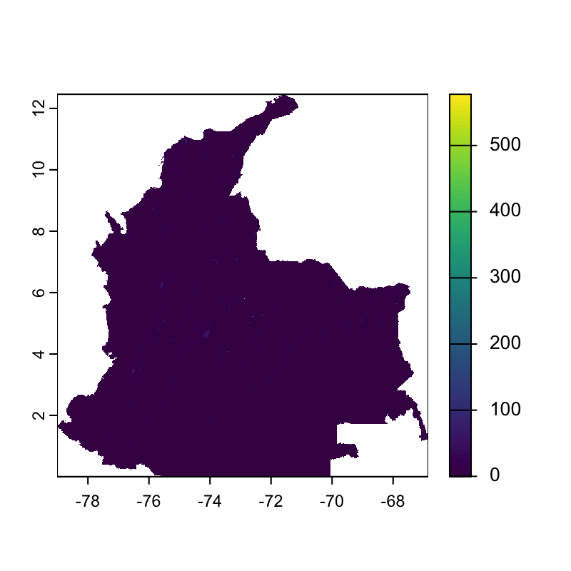

```r
plot(nl_r)    # Visualización
```

Recorte espacial (clip con un polígono)

```r
cali <- getbb(place_name="Cali, Colombia",
              featuretype="boundary:administrative",
              format_out="sf_polygon")
cali <- cali[2,]
mapview(cali)
```

[interactive chart not shown]

```r
cali_r <- crop(nl_r , cali , mask=T)
mapview(cali_r)
```

[interactive chart not shown]

Ver el contenido

```r
df <- as.data.frame(cali_r , xy = TRUE)
```

```r
mnz <- read_rds("https://eduard-martinez.github.io/blog/intro_raster_in_r/data/manzanas_cali.rds") %>% st_as_sf()
mnz
```

```
## Simple feature collection with 15658 features and 2 fields
## Geometry type: MULTIPOLYGON
## Dimension:     XY
## Bounding box:  xmin: -76.63822 ymin: 3.297279 xmax: -76.46032 ymax: 3.521935
## Geodetic CRS:  MAGNA-SIRGAS
## # A tibble: 15,658 × 3
##    manz_ccdgo tp27_perso                                                geometry
##    <chr>           <dbl>                                      <MULTIPOLYGON [°]>
##  1 01                246 (((-76.5736 3.453689, -76.57297 3.453553, -76.57291 3.…
##  2 02                 90 (((-76.57208 3.453995, -76.57208 3.453599, -76.57213 3…
##  3 04                  0 (((-76.57437 3.453682, -76.57445 3.453696, -76.57453 3…
##  4 11                189 (((-76.5747 3.455425, -76.57469 3.455418, -76.57471 3.…
##  5 12                257 (((-76.57574 3.454616, -76.5759 3.454683, -76.57589 3.…
##  6 13                230 (((-76.57596 3.455676, -76.57592 3.45576, -76.57592 3.…
##  7 14                117 (((-76.57655 3.455408, -76.57645 3.455547, -76.57639 3…
##  8 15                133 (((-76.577 3.455671, -76.57691 3.455745, -76.57659 3.4…
##  9 16                276 (((-76.57737 3.456761, -76.57718 3.456901, -76.57705 3…
## 10 19                 93 (((-76.57535 3.456573, -76.57533 3.456564, -76.57517 3…
## # ℹ 15,648 more rows
```

## 7. Extraer valores por punto o polígono

```r
# Por punto
pts <- vect(data.frame(x = -76.5, y = 3.4), type = "points", crs = crs(r))
extract(r, pts)

# Por polígono
extract(r, shape, fun = mean)
```

## 8. Guardar un raster procesado

```r
writeRaster(r_mask, "salida/recorte.tif", overwrite = TRUE)
```

```r
## st_as_sf
puntos_quilla = st_as_sf(x = l_quilla, as_points = T, na.rm = T) # raster to sf (points)
puntos_quilla

poly_quilla = st_as_sf(x = l_quilla, as_points = F, na.rm = T) # raster to sf (polygons)
poly_quilla

## Plot data
ggplot() +
geom_sf(data = puntos_quilla , aes(col=date_202301))  +
scale_color_viridis(option="A" , na.value='white') +
geom_sf(data=quilla , fill=NA , col="green") + theme_test()

ggplot() +
geom_sf(data = poly_quilla , aes(fill=date_202301),col=NA)  +
scale_fill_viridis(option="A" , na.value='white') +
geom_sf(data=quilla , fill=NA , col="green") + theme_test()
```

[output not shown]

### **Referencias**

- Lovelace, R., Nowosad, J., & Muenchow, J. (2019). **Geocomputation with R.** [[Ver aquí]](https://geocompr.robinlovelace.net)
  - Cap. 4: Spatial Data Operations
  - Cap. 5: Geometry Operations
  - Cap. 6: Reprojecting geographic data
  - Cap. 11: Statistical learning
- Bivand, R. S., Pebesma, E. J., Gómez-Rubio, V., & Pebesma, E. J. (2013). **Applied spatial data analysis with R.** [[Ver aquí]](https://csgillespie.github.io/efficientR/)
  - Cap. 4: Spatial Data Import and Export
  - Cap. 7: Spatial Point Pattern Analysis
  - Cap. 8: Interpolation and Geostatistics